# 20202_M2.955_PAC3_Enunciat-Copy1

[figure not shown]

Aleix Sicília

Practical case in (*Data science*)

Advanced data mining

# Introduction

The aim of this report is to outline the importance of managing and comprehending data in real-world projects. In a very short term, it is highly plausible that many AI developments could influence in our day-to-day decisions. Hence, it seems far-fetched that we do not understand how these systems are designed per se.

In the upcoming future, it could give rise to plenty of hefty challenges. Be that as it may, it could sow the seeds of other cons. To name but a few, inequalities could rise, roles propagation could be perpetuated or social bipolarity could be extended.

Thus, it happens to be significant that we must interpret and understand their applications. My insight is that there are some easy-to-interpret algorithms such as decision trees. Albeit, we must give prominence to the fact that other methods such as Decision Gradient are a black box (they could run smoothly with a great precision. However, there is a setback in its difficult comprehension). Indeed, I dare say that the best way to democratize AI is reviewed it thoroughly.

In this practical case I want to show you how banks could concede a credit. In this small project we will observe the importance of obtaining complete data, how to preprocess it, how to manage different algorithms/methods, and how to interpret them. Two methods called Decision Tree and Gradient Boosting Classifier will be compared. Each dataset will be different, so we have to fit our solution to each case.

[1] This databased will be based on public data from Spanish Government. Firstly, we should install their required libraries. We will use a program called Python. This small project is inspired in a practical case of the subject "Minería de datos avanzados" from UOC.

```python
# Import some libraries
import numpy as np
import pandas as pd
import seaborn as sns

from sklearn import datasets
from sklearn.ensemble import GradientBoostingClassifier, RandomForestClassifier
from sklearn.linear_model import LogisticRegression
from sklearn.metrics import accuracy_score, confusion_matrix
from sklearn.model_selection import train_test_split, GridSearchCV
from sklearn.naive_bayes import GaussianNB
from sklearn.neighbors import KNeighborsClassifier
from sklearn.preprocessing import OneHotEncoder
from sklearn.svm import SVC
from sklearn.tree import DecisionTreeClassifier, export_graphviz
from sklearn.utils import check_random_state

# Decision tree visualization
from IPython.display import Image
import pydotplus
from six import StringIO

# UMAP dimensionality reduction
import umap

# Visualisation
from matplotlib.colors import ListedColormap
import matplotlib.pyplot as plt

%matplotlib inline
```

# 1. Predicting whether a mortgage has been conceded

Firstly, I would like to place emphasis on the fact that we will have to analyze data. If historical data is dirty, we have to realize we might fix it. Sometimes our society has an improper past. By illustration, whether we want our past is patriarchal, our system could concede more credit to males than females.

```python
hipotecas = pd.read_csv("hipotecas.csv")
hipotecas.head(10)
```

|  | ingresos | gastos_comunes | pago_coche | gastos_otros | ahorros | vivienda | estado_civil | hijos | trabajo | hipoteca |
| --- | --- | --- | --- | --- | --- | --- | --- | --- | --- | --- |
| 0 | 6000 | 1000 | 0 | 600 | 50000 | 400000 | 0 | 2 | 2 | 1 |
| 1 | 6745 | 944 | 123 | 429 | 43240 | 636897 | 1 | 3 | 6 | 0 |
| 2 | 6455 | 1033 | 98 | 795 | 57463 | 321779 | 2 | 1 | 8 | 1 |
| 3 | 7098 | 1278 | 15 | 254 | 54506 | 660933 | 0 | 0 | 3 | 0 |
| 4 | 6167 | 863 | 223 | 520 | 41512 | 348932 | 0 | 0 | 3 | 1 |
| 5 | 5692 | 911 | 11 | 325 | 50875 | 360863 | 1 | 4 | 5 | 1 |
| 6 | 6830 | 1298 | 345 | 309 | 46761 | 429812 | 1 | 1 | 5 | 1 |
| 7 | 6470 | 1035 | 39 | 782 | 57439 | 606291 | 0 | 0 | 1 | 0 |
| 8 | 6251 | 1250 | 209 | 571 | 50503 | 291010 | 0 | 0 | 3 | 1 |
| 9 | 6987 | 1258 | 252 | 245 | 40611 | 324098 | 2 | 1 | 7 | 1 |

## 2.1. Descriptive analysis

Given this dataset, an exploratory analysis has to be done. we Must to understand and interpret our dataset.

**First and foremost, we have to calculate frequencies regarding the variable target (mortgage).** Distribution of each categorical variable has to be analysed in bar graphs. Additionally, an histogram has to be visualized in numerical data.

```python
# Firstly, numerical variables will be explored
feats_to_explore_num = ['ingresos', 'gastos_comunes', 'pago_coche', 'gastos_otros', 'ahorros','vivienda']
y = hipotecas["hipoteca"]
```

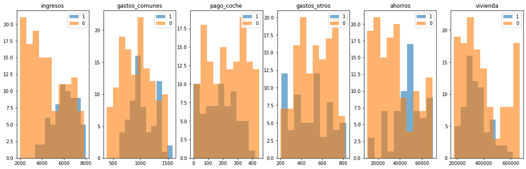

```python
# Plot has to be prepared:
fig, axs = plt.subplots(nrows=1, ncols=len(feats_to_explore_num), figsize=(20,6))

# A graph for each feats_to_explore:
for i, featName in enumerate(feats_to_explore_num):
    # An histogram per each numerical variable:
    for diag in y.unique():
        axs[i].hist(hipotecas.loc[y==diag, featName], alpha=0.6, label=diag)
        axs[i].set_title(featName)
        axs[i].legend(loc='upper right')
```

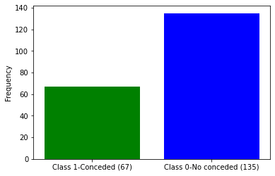

```python
# A categorical has to be done
# Additionally
# We want to explore the number of concessions
y = hipotecas["hipoteca"]
counts = [y.value_counts()[1], y.value_counts()[0]]
place = np.arange(len(counts))
# Plot bar
plt.bar(place, counts, color=('green','blue'))

# We have to visualise each label
plt.xticks(place, ('Class 1-Conceded ('+str(y.value_counts()[1])+')',
                   'Class 0-No conceded ('+str(y.value_counts()[0])+')'))
plt.ylabel('Frequency')
```

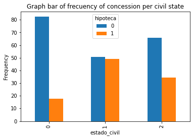

```python
# A categorical analysis has to be done
# Graph bar in function of target

# Graph bar of frecuency of concession per civil state
plot = pd.crosstab(index=hipotecas['estado_civil'],
            columns=hipotecas['hipoteca']).apply(lambda r: r/r.sum() *100,
                                              axis=1).plot(kind='bar')
plot.set_title('Graph bar of frecuency of concession per civil state')
plot.set_ylabel('Frequency')
```

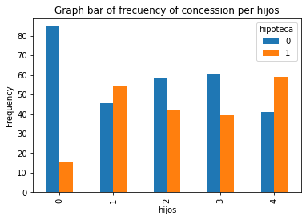

```python
# A categorical analysis has to be done
# Graph bar in function of target

# Graph bar of frecuency of concession per number of children
plot = pd.crosstab(index=hipotecas['hijos'],
            columns=hipotecas['hipoteca']).apply(lambda r: r/r.sum() *100,
                                              axis=1).plot(kind='bar')
plot.set_title('Graph bar of frecuency of concession per hijos')
plot.set_ylabel('Frequency')
```

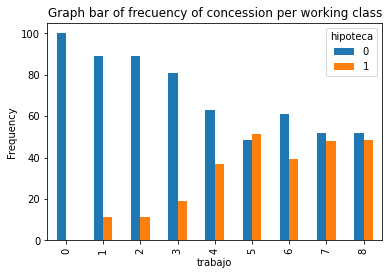

```python
# A categorical analysis has to be done
# Graph bar in function of target

# Graph bar of frecuency of concession per type of work
plot = pd.crosstab(index=hipotecas['trabajo'],
            columns=hipotecas['hipoteca']).apply(lambda r: r/r.sum() *100,
                                              axis=1).plot(kind='bar')
plot.set_title('Graph bar of frecuency of concession per working class')
plot.set_ylabel('Frequency')
```

### Interpretation of this step

On the bright side of having a marriage, there is an increasing number of percentages in the concessions (more than 30%). It could be related to the fact that the odds of being unemployed are less than having a lot of members.

Furthermore, on the upside of having a large number of children could influence on the concession of the mortgage. [2] According to INE, Spanish birth rate is 0,86 children per person. Generally, this survey asserts that there is a certain trend that shows that as more familiar resource gain, the number of children increase. Come what may, it is highly plausible that some unstructured families could have a large family, too. Hence, in a statistical analysis we could observe there is an inaccurate rate of variance's errors distributions.

## 2.2. Preprocessing data

The next step will have to be done is cleaning data. It is an essential step in the design of this model.

**First step:** Check null values.

```python
# Check null values
hipotecas.isnull().sum()
# df_brcan.isna().any()
# There is not missing data
```

```
ingresos          0
gastos_comunes    0
pago_coche        0
gastos_otros      0
ahorros           0
vivienda          0
estado_civil      0
hijos             0
trabajo           0
hipoteca          0
dtype: int64
```

**Second step:** Modify and fix the data - We will have to group by diferent expenditures such as pago_coche, gastos_comunes, gastos_otros in a new column called "total_cost" - Calculate the total amount to finance. Consequently, a new column will be called as "To_finance" - Drop all old varibles

```python
# Total amount of expenditure
hipotecas['total_cost'] = hipotecas['pago_coche']+hipotecas['gastos_comunes']+hipotecas['gastos_otros']
# Total amount to finance
hipotecas['To_finance'] = hipotecas['vivienda']-hipotecas['ahorros']
# Drop all non necessary columns
new_hipotecas = hipotecas.drop(columns=['gastos_comunes','pago_coche','gastos_otros','ahorros','vivienda'])
new_hipotecas
```

|  | ingresos | estado_civil | hijos | trabajo | hipoteca | total_cost | To_finance |
| --- | --- | --- | --- | --- | --- | --- | --- |
| 0 | 6000 | 0 | 2 | 2 | 1 | 1600 | 350000 |
| 1 | 6745 | 1 | 3 | 6 | 0 | 1496 | 593657 |
| 2 | 6455 | 2 | 1 | 8 | 1 | 1926 | 264316 |
| 3 | 7098 | 0 | 0 | 3 | 0 | 1547 | 606427 |
| 4 | 6167 | 0 | 0 | 3 | 1 | 1606 | 307420 |
| ... | ... | ... | ... | ... | ... | ... | ... |
| 197 | 3831 | 0 | 0 | 2 | 0 | 1530 | 352397 |
| 198 | 3961 | 2 | 3 | 8 | 0 | 1775 | 258541 |
| 199 | 3184 | 1 | 3 | 8 | 0 | 1915 | 352460 |
| 200 | 3334 | 1 | 2 | 5 | 0 | 1888 | 356907 |
| 201 | 3988 | 0 | 0 | 4 | 0 | 1644 | 245600 |

202 rows × 7 columns

Next step will be checking all correlations between all numerical feautres. Hence, we can observe if we have to combine some variables in a new column. Stay tuned, correlation does not imply causation.

**Conclusion:** The following graph shows the correlation in all numerical features. If there are two variables with a correaltion greater than 80%, some of them could be dropped. Heatmap (seaborn) library will be used.

```python
# Firstly, we will observe correlation in the old dataset
num_hipotecas_no_proc = hipotecas.drop(columns=['estado_civil','hijos','trabajo','hipoteca'])
corr_all1 = num_hipotecas_no_proc.corr()
corr_all1.style.background_gradient(cmap='coolwarm').set_precision(2)
```

|  | ingresos | gastos_comunes | pago_coche | gastos_otros | ahorros | vivienda | total_cost | To_finance |
| --- | --- | --- | --- | --- | --- | --- | --- | --- |
| ingresos | 1.00 | 0.56 | -0.11 | -0.12 | 0.71 | 0.61 | 0.36 | 0.56 |
| gastos_comunes | 0.56 | 1.00 | -0.05 | -0.10 | 0.21 | 0.20 | 0.77 | 0.19 |
| pago_coche | -0.11 | -0.05 | 1.00 | 0.01 | -0.19 | -0.09 | 0.34 | -0.08 |
| gastos_otros | -0.12 | -0.10 | 0.01 | 1.00 | -0.06 | -0.05 | 0.44 | -0.05 |
| ahorros | 0.71 | 0.21 | -0.19 | -0.06 | 1.00 | 0.61 | 0.07 | 0.52 |
| vivienda | 0.61 | 0.20 | -0.09 | -0.05 | 0.61 | 1.00 | 0.11 | 0.99 |
| total_cost | 0.36 | 0.77 | 0.34 | 0.44 | 0.07 | 0.11 | 1.00 | 0.11 |
| To_finance | 0.56 | 0.19 | -0.08 | -0.05 | 0.52 | 0.99 | 0.11 | 1.00 |

#### Interpretation

```python
# Preprocessed dataset
num_hipotecas_proc = new_hipotecas.drop(columns=['estado_civil','hijos','trabajo','hipoteca'])
corr_all2 = num_hipotecas_proc.corr()
corr_all2.style.background_gradient(cmap='coolwarm').set_precision(2)
```

|  | ingresos | total_cost | To_finance |
| --- | --- | --- | --- |
| ingresos | 1.00 | 0.36 | 0.56 |
| total_cost | 0.36 | 1.00 | 0.11 |
| To_finance | 0.56 | 0.11 | 1.00 |

#### Interpretation

In this graph, we can observe that there are not significiant correlation between variables. By the same token, the most correlated variables are income and the amount to "To_finance" (56% correlation).

In the next step we will check it in a numerical way.

```python
# Select the upper triangle in correlation
upper = corr_all2.where(np.triu(np.ones(corr_all2.shape), k=1).astype(np.bool))

# We will check values with a correlation greater than 80%
highCorr = [column for column in upper.columns if any(upper[column] > 0.8)]
print("Correlation greater than 80%")
highCorr
```

```
Correlation greater than 80%
```

```
[]
```

#### Interpretation

There is not any correlation greater than 80%. Hence, it is not necessary to drop any column.

In the next analysis we will check an exploratory analysis with the new processed dataset.

**Case:** We will have to plot the graph bar and histograms.

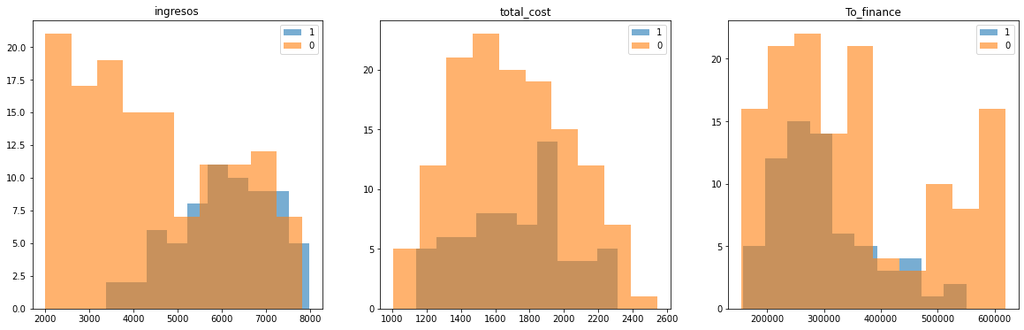

```python
# Firstly, I will plot a histogram with numerical variables
feats_to_explore_num = ['ingresos', 'total_cost','To_finance']
y = new_hipotecas["hipoteca"]
# The next figure will be prepared
fig, axs = plt.subplots(nrows=1, ncols=len(feats_to_explore_num), figsize=(20,6))

# A graphic per each feats_to_explore:
for i, featName in enumerate(feats_to_explore_num):
    # An histogram per each numerical var:
    for diag in y.unique():
        axs[i].hist(new_hipotecas.loc[y==diag, featName], alpha=0.6, label=diag)
        axs[i].set_title(featName)
        axs[i].legend(loc='upper right')
```

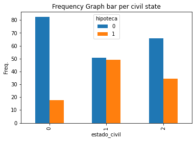

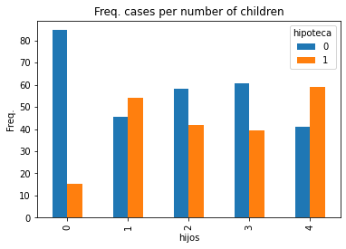

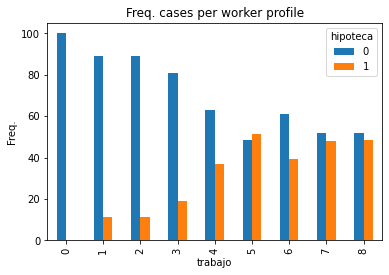

```python
# Graph bar

# Graph bar per civil state
plot = pd.crosstab(index=new_hipotecas['estado_civil'],
            columns=new_hipotecas['hipoteca']).apply(lambda r: r/r.sum() *100,
                                              axis=1).plot(kind='bar')
plot.set_title('Frequency Graph bar per civil state')
plot.set_ylabel('Freq.')

# Graph bar per number of children
plot = pd.crosstab(index=hipotecas['hijos'],
            columns=new_hipotecas['hipoteca']).apply(lambda r: r/r.sum() *100,
                                              axis=1).plot(kind='bar')
plot.set_title('Freq. cases per number of children')
plot.set_ylabel('Freq.')

# Graph bar per number per worker profile
plot = pd.crosstab(index=hipotecas['trabajo'],
            columns=new_hipotecas['hipoteca']).apply(lambda r: r/r.sum() *100,
                                              axis=1).plot(kind='bar')
plot.set_title('Freq. cases per worker profile')
plot.set_ylabel('Freq.')
```

#### Analysis

As it has been previously mencioned, we can observe the most incluential variables such as income and amount to finance. However, total expenditure does not seem to have a significant influence. According to the professional variable, we can observe that there is a certain trend regarding each employee profile.

Furthermore, in order to enhace our statistical analysis we will have to apply a one-hot-encoading in the required categorial data. A one hot encoding allows the representation of categorical data to be more expressive. Many machine learning algorithms cannot work with categorical data directly. The categories must be converted into numbers.

**Upcoming step:** Apply OneHotEncoder from sklearn.preprocessing.

```python
# OneHotEncoder will be applied in estat_civil and trabajo
import pandas as pd
import numpy as np
from sklearn.preprocessing import OneHotEncoder
# creating instance of one-hot-encoder
encoder = OneHotEncoder()
# Seleccion of variables
enc_hipotecas = new_hipotecas[['estado_civil','trabajo']]
encoder.fit(enc_hipotecas)
# Transform a numpy array
resultat = encoder.transform(enc_hipotecas).toarray()
# New datafram
df = pd.DataFrame(resultat, columns = encoder.get_feature_names())
# Joining dataframe with key values
new_hipotecas = new_hipotecas.join(df)
new_hipotecas
```

|  | ingresos | estado_civil | hijos | trabajo | hipoteca | total_cost | To_finance | x0_0 | x0_1 | x0_2 | x1_0 | x1_1 | x1_2 | x1_3 | x1_4 | x1_5 | x1_6 | x1_7 | x1_8 |
| --- | --- | --- | --- | --- | --- | --- | --- | --- | --- | --- | --- | --- | --- | --- | --- | --- | --- | --- | --- |
| 0 | 6000 | 0 | 2 | 2 | 1 | 1600 | 350000 | 1.0 | 0.0 | 0.0 | 0.0 | 0.0 | 1.0 | 0.0 | 0.0 | 0.0 | 0.0 | 0.0 | 0.0 |
| 1 | 6745 | 1 | 3 | 6 | 0 | 1496 | 593657 | 0.0 | 1.0 | 0.0 | 0.0 | 0.0 | 0.0 | 0.0 | 0.0 | 0.0 | 1.0 | 0.0 | 0.0 |
| 2 | 6455 | 2 | 1 | 8 | 1 | 1926 | 264316 | 0.0 | 0.0 | 1.0 | 0.0 | 0.0 | 0.0 | 0.0 | 0.0 | 0.0 | 0.0 | 0.0 | 1.0 |
| 3 | 7098 | 0 | 0 | 3 | 0 | 1547 | 606427 | 1.0 | 0.0 | 0.0 | 0.0 | 0.0 | 0.0 | 1.0 | 0.0 | 0.0 | 0.0 | 0.0 | 0.0 |
| 4 | 6167 | 0 | 0 | 3 | 1 | 1606 | 307420 | 1.0 | 0.0 | 0.0 | 0.0 | 0.0 | 0.0 | 1.0 | 0.0 | 0.0 | 0.0 | 0.0 | 0.0 |
| ... | ... | ... | ... | ... | ... | ... | ... | ... | ... | ... | ... | ... | ... | ... | ... | ... | ... | ... | ... |
| 197 | 3831 | 0 | 0 | 2 | 0 | 1530 | 352397 | 1.0 | 0.0 | 0.0 | 0.0 | 0.0 | 1.0 | 0.0 | 0.0 | 0.0 | 0.0 | 0.0 | 0.0 |
| 198 | 3961 | 2 | 3 | 8 | 0 | 1775 | 258541 | 0.0 | 0.0 | 1.0 | 0.0 | 0.0 | 0.0 | 0.0 | 0.0 | 0.0 | 0.0 | 0.0 | 1.0 |
| 199 | 3184 | 1 | 3 | 8 | 0 | 1915 | 352460 | 0.0 | 1.0 | 0.0 | 0.0 | 0.0 | 0.0 | 0.0 | 0.0 | 0.0 | 0.0 | 0.0 | 1.0 |
| 200 | 3334 | 1 | 2 | 5 | 0 | 1888 | 356907 | 0.0 | 1.0 | 0.0 | 0.0 | 0.0 | 0.0 | 0.0 | 0.0 | 1.0 | 0.0 | 0.0 | 0.0 |
| 201 | 3988 | 0 | 0 | 4 | 0 | 1644 | 245600 | 1.0 | 0.0 | 0.0 | 0.0 | 0.0 | 0.0 | 0.0 | 1.0 | 0.0 | 0.0 | 0.0 | 0.0 |

202 rows × 19 columns

```python
# We will have to drop non necessary columns
# It will be civil state and trabajo
new_hipotecas = new_hipotecas.drop(columns=['estado_civil','trabajo'])
new_hipotecas
```

|  | ingresos | hijos | hipoteca | total_cost | To_finance | x0_0 | x0_1 | x0_2 | x1_0 | x1_1 | x1_2 | x1_3 | x1_4 | x1_5 | x1_6 | x1_7 | x1_8 |
| --- | --- | --- | --- | --- | --- | --- | --- | --- | --- | --- | --- | --- | --- | --- | --- | --- | --- |
| 0 | 6000 | 2 | 1 | 1600 | 350000 | 1.0 | 0.0 | 0.0 | 0.0 | 0.0 | 1.0 | 0.0 | 0.0 | 0.0 | 0.0 | 0.0 | 0.0 |
| 1 | 6745 | 3 | 0 | 1496 | 593657 | 0.0 | 1.0 | 0.0 | 0.0 | 0.0 | 0.0 | 0.0 | 0.0 | 0.0 | 1.0 | 0.0 | 0.0 |
| 2 | 6455 | 1 | 1 | 1926 | 264316 | 0.0 | 0.0 | 1.0 | 0.0 | 0.0 | 0.0 | 0.0 | 0.0 | 0.0 | 0.0 | 0.0 | 1.0 |
| 3 | 7098 | 0 | 0 | 1547 | 606427 | 1.0 | 0.0 | 0.0 | 0.0 | 0.0 | 0.0 | 1.0 | 0.0 | 0.0 | 0.0 | 0.0 | 0.0 |
| 4 | 6167 | 0 | 1 | 1606 | 307420 | 1.0 | 0.0 | 0.0 | 0.0 | 0.0 | 0.0 | 1.0 | 0.0 | 0.0 | 0.0 | 0.0 | 0.0 |
| ... | ... | ... | ... | ... | ... | ... | ... | ... | ... | ... | ... | ... | ... | ... | ... | ... | ... |
| 197 | 3831 | 0 | 0 | 1530 | 352397 | 1.0 | 0.0 | 0.0 | 0.0 | 0.0 | 1.0 | 0.0 | 0.0 | 0.0 | 0.0 | 0.0 | 0.0 |
| 198 | 3961 | 3 | 0 | 1775 | 258541 | 0.0 | 0.0 | 1.0 | 0.0 | 0.0 | 0.0 | 0.0 | 0.0 | 0.0 | 0.0 | 0.0 | 1.0 |
| 199 | 3184 | 3 | 0 | 1915 | 352460 | 0.0 | 1.0 | 0.0 | 0.0 | 0.0 | 0.0 | 0.0 | 0.0 | 0.0 | 0.0 | 0.0 | 1.0 |
| 200 | 3334 | 2 | 0 | 1888 | 356907 | 0.0 | 1.0 | 0.0 | 0.0 | 0.0 | 0.0 | 0.0 | 0.0 | 1.0 | 0.0 | 0.0 | 0.0 |
| 201 | 3988 | 0 | 0 | 1644 | 245600 | 1.0 | 0.0 | 0.0 | 0.0 | 0.0 | 0.0 | 0.0 | 1.0 | 0.0 | 0.0 | 0.0 | 0.0 |

202 rows × 17 columns

**Analyzing:** Why do we use one hot encoding?

#### Interpretation

[3] One-hot-encoding has to be used in order to normalising data as some ML algorithms cannot work with categorical data directly.

By a way of illustration, a decision tree can be learned directly from categorical data with no data transform required (this depends on the specific implementation). Be that as it may, many machine learning algorithms cannot operate on label data directly. They require all input variables and output variables to be numeric.

In general, this is mostly a constraint of the efficient implementation of machine learning algorithms rather than hard limitations on the algorithms themselves.

This means that categorical data must be converted to a numerical form. If the categorical variable is an output variable, you may also want to convert predictions by the model back into a categorical form in order to present them or use them in some application.

## 2.3. Training a model

In the upcoming step, a model will be trained.

**Case:** We will have to split this dataset up *dataset* in two pars *train* (80% data) i *test* (20% data). It will have the following terms X_train, X_test, y_train, y_test. We will use random_state=24.

```python
# New dataset
X = new_hipotecas.drop(columns=['hipoteca'])
Y = new_hipotecas['hipoteca']
X
X_train, X_test, y_train, y_test = train_test_split(X, y, test_size=0.2, random_state=24)
print (X_train.shape, y_train.shape)
print (X_test.shape, y_test.shape)
```

```
(161, 16) (161,)
(41, 16) (41,)
```

```python
columns_names = X.columns.values
columns_names_list = list(columns_names)
columns_names_list
Y_valors=['0','1']
```

**Implementation:** A new simple decision tree with max_depth=5 will be used to filter the dataset called "hipotecas" in the training set. Decision tree will be plotted. We will have to calculate accuracy in the confusion matrix.

```
|--- feature_0 <= 4506.00
|   |--- feature_14 <= 0.50
|   |   |--- class: 0
|   |--- feature_14 >  0.50
|   |   |--- feature_0 <= 3159.50
|   |   |   |--- class: 0
|   |   |--- feature_0 >  3159.50
|   |   |   |--- feature_3 <= 239693.50
|   |   |   |   |--- class: 1
|   |   |   |--- feature_3 >  239693.50
|   |   |   |   |--- class: 0
|--- feature_0 >  4506.00
|   |--- feature_3 <= 457149.00
|   |   |--- feature_7 <= 0.50
|   |   |   |--- feature_0 <= 4947.50
|   |   |   |   |--- feature_3 <= 237411.50
|   |   |   |   |   |--- class: 1
|   |   |   |   |--- feature_3 >  237411.50
|   |   |   |   |   |--- class: 0
|   |   |   |--- feature_0 >  4947.50
|   |   |   |   |--- feature_11 <= 0.50
|   |   |   |   |   |--- class: 1
|   |   |   |   |--- feature_11 >  0.50
|   |   |   |   |   |--- class: 1
|   |   |--- feature_7 >  0.50
|   |   |   |--- class: 0
|   |--- feature_3 >  457149.00
|   |   |--- feature_15 <= 0.50
|   |   |   |--- feature_1 <= 3.50
|   |   |   |   |--- feature_0 <= 7343.00
|   |   |   |   |   |--- class: 0
|   |   |   |   |--- feature_0 >  7343.00
|   |   |   |   |   |--- class: 0
|   |   |   |--- feature_1 >  3.50
|   |   |   |   |--- class: 1
|   |   |--- feature_15 >  0.50
|   |   |   |--- class: 1
```

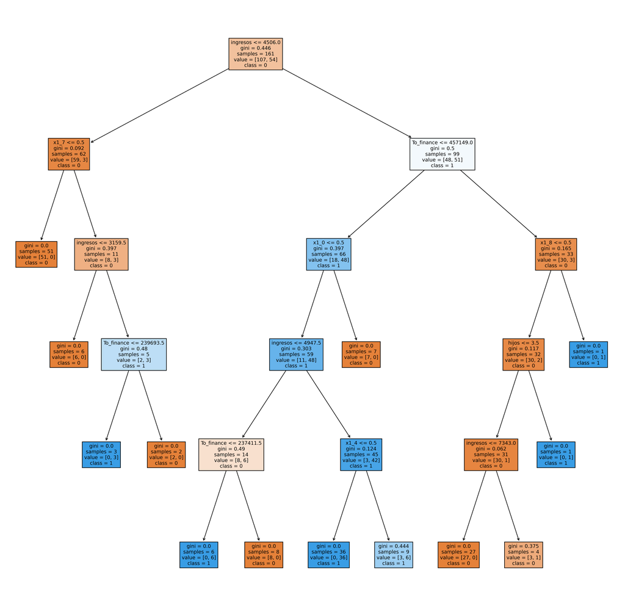

```python
from sklearn import tree
import matplotlib.pyplot as plt
from sklearn.tree import export_graphviz
import pydotplus
# Decision tree with max_depth=5
clf_DTC = DecisionTreeClassifier(max_depth=5)
model = clf_DTC.fit(X_train, y_train)
text_representation = tree.export_text(clf_DTC)
fig, axs = plt.subplots(nrows=1, ncols=1, figsize=(20,20), dpi=300)
print(text_representation)
# DOT data
tree.plot_tree(clf_DTC,
                  feature_names=columns_names_list,
                  class_names=Y_valors,
                  filled=True
                           )
plt.show()
```

```
Accuracy in training model 97.52 %
Accuracy in testing model 80.49 %
Classification Report
              precision    recall  f1-score   support

           0       0.92      0.79      0.85        28
           1       0.65      0.85      0.73        13

    accuracy                           0.80        41
   macro avg       0.78      0.82      0.79        41
weighted avg       0.83      0.80      0.81        41
```

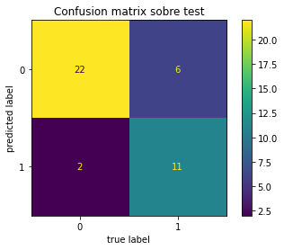

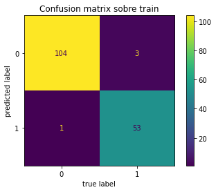

```python
from sklearn.metrics import classification_report, confusion_matrix
#Import metrics class from sklearn
from sklearn import metrics
from sklearn.metrics import plot_confusion_matrix

predicted = clf_DTC.predict(X_test)

# Confusion matrix in testing set
metrics.accuracy_score(predicted, y_test)
plot_confusion_matrix(clf_DTC, X_test, y_test)

plt.title('Confusion matrix sobre test')
plt.xlabel('true label')
plt.ylabel('predicted label');

# Confusion matrix in training set
plot_confusion_matrix(clf_DTC, X_train, y_train)

plt.title('Confusion matrix sobre train')
plt.xlabel('true label')
plt.ylabel('predicted label');

# Precision in training model
score = clf_DTC.score(X_train,y_train)*100

print("Accuracy in training model {0:.2f} %".format(score))

# Precision in testing model
preds = clf_DTC.predict(X_test)

accuracy = np.true_divide(np.sum(preds == y_test), preds.shape[0])*100
cnf_matrix = confusion_matrix(y_test, preds)

print("Accuracy in testing model {0:.2f} %".format(accuracy))

# We will observe the recall values
print("Classification Report")
print(classification_report(y_test, preds))
```

```python
# To prevent overfitting
# We will observe the optimal CV Grid Search

param_grid = {"max_depth": range(4, 10), "min_samples_split": [2, 10, 20, 50, 100]}

grid_search = GridSearchCV(clf_DTC, param_grid=param_grid, cv=4)
grid_search.fit(X_train, y_train)

means = grid_search.cv_results_["mean_test_score"]
stds = grid_search.cv_results_["std_test_score"]
params = grid_search.cv_results_['params']

for mean, std, pms in zip(means, stds, params):
    print("Average accuracy: {:.2f} +/- {:.2f} with parameters {}".format(mean*100, std*100, pms))
```

```
Average accuracy: 84.42 +/- 5.48 with parameters {'max_depth': 4, 'min_samples_split': 2}
Average accuracy: 83.17 +/- 7.63 with parameters {'max_depth': 4, 'min_samples_split': 10}
Average accuracy: 83.80 +/- 6.79 with parameters {'max_depth': 4, 'min_samples_split': 20}
Average accuracy: 80.11 +/- 3.15 with parameters {'max_depth': 4, 'min_samples_split': 50}
Average accuracy: 62.09 +/- 3.47 with parameters {'max_depth': 4, 'min_samples_split': 100}
Average accuracy: 82.58 +/- 4.76 with parameters {'max_depth': 5, 'min_samples_split': 2}
Average accuracy: 83.83 +/- 7.43 with parameters {'max_depth': 5, 'min_samples_split': 10}
Average accuracy: 83.80 +/- 6.79 with parameters {'max_depth': 5, 'min_samples_split': 20}
Average accuracy: 80.11 +/- 3.15 with parameters {'max_depth': 5, 'min_samples_split': 50}
Average accuracy: 62.09 +/- 3.47 with parameters {'max_depth': 5, 'min_samples_split': 100}
Average accuracy: 86.30 +/- 5.50 with parameters {'max_depth': 6, 'min_samples_split': 2}
Average accuracy: 85.66 +/- 8.94 with parameters {'max_depth': 6, 'min_samples_split': 10}
Average accuracy: 83.80 +/- 6.79 with parameters {'max_depth': 6, 'min_samples_split': 20}
Average accuracy: 80.11 +/- 3.15 with parameters {'max_depth': 6, 'min_samples_split': 50}
Average accuracy: 62.09 +/- 3.47 with parameters {'max_depth': 6, 'min_samples_split': 100}
Average accuracy: 86.95 +/- 2.74 with parameters {'max_depth': 7, 'min_samples_split': 2}
Average accuracy: 81.95 +/- 5.77 with parameters {'max_depth': 7, 'min_samples_split': 10}
Average accuracy: 83.80 +/- 6.79 with parameters {'max_depth': 7, 'min_samples_split': 20}
Average accuracy: 80.11 +/- 3.15 with parameters {'max_depth': 7, 'min_samples_split': 50}
Average accuracy: 62.09 +/- 3.47 with parameters {'max_depth': 7, 'min_samples_split': 100}
Average accuracy: 86.33 +/- 5.17 with parameters {'max_depth': 8, 'min_samples_split': 2}
Average accuracy: 83.78 +/- 8.05 with parameters {'max_depth': 8, 'min_samples_split': 10}
Average accuracy: 83.80 +/- 6.79 with parameters {'max_depth': 8, 'min_samples_split': 20}
Average accuracy: 80.11 +/- 3.15 with parameters {'max_depth': 8, 'min_samples_split': 50}
Average accuracy: 62.09 +/- 3.47 with parameters {'max_depth': 8, 'min_samples_split': 100}
Average accuracy: 85.67 +/- 5.47 with parameters {'max_depth': 9, 'min_samples_split': 2}
Average accuracy: 83.83 +/- 7.43 with parameters {'max_depth': 9, 'min_samples_split': 10}
Average accuracy: 83.80 +/- 6.79 with parameters {'max_depth': 9, 'min_samples_split': 20}
Average accuracy: 80.11 +/- 3.15 with parameters {'max_depth': 9, 'min_samples_split': 50}
Average accuracy: 62.09 +/- 3.47 with parameters {'max_depth': 9, 'min_samples_split': 100}
```

**Analysis:** What are the most important variables? Have you got rather a good precision in testing set? Has overfitting been caused?